# Лабораторная работа №2

Управление пользователями и группами

Суворова Дарья Евгеньевна

1032253638@rudn.ru

Российский университет дружбы народов

2026-03-05

# Информация

## Докладчик

- Суворова Дарья Евгеньевна
- студент группы НПИ-бд-02-25
- Российский университет дружбы народов им. П. Лумумбы
- 1032253638@rudn.ru
- https://github.com/suvorovade-cyber

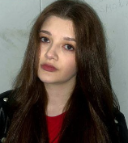

# Вводная часть

## Цели и задачи

Получить представление о работе с учётными записями пользователей и группами пользователей в операционной системе типа Linux.

## Задание

1. Прочитайте справочное описание man по командам ls, whoami, id, groups, su, sudo, passwd, vi, visudo, useradd, usermod, userdel, groupadd, groupdel.
2. Выполните действия по переключению между учётными записями пользователей, по управлению учётными записями пользователей (раздел 2.4.1).
3. Выполните действия по созданию пользователей и управлению их учётными записями (раздел 2.4.2).
4. Выполните действия по работе с группами пользователей (раздел 2.4.3).

# Выполнение лабораторной работы

1. Чтение справочного описания различных команд с помощью команды man.

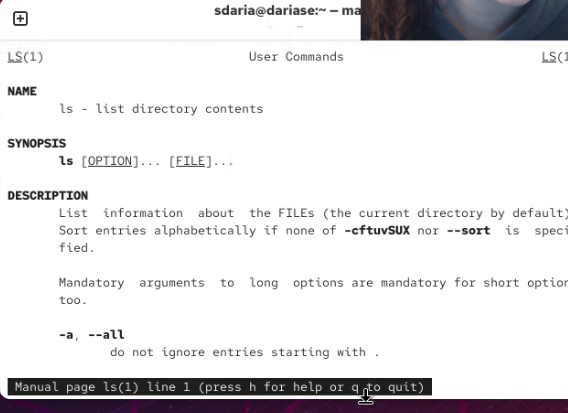

Рисунок 1: Справочное описание команды ls

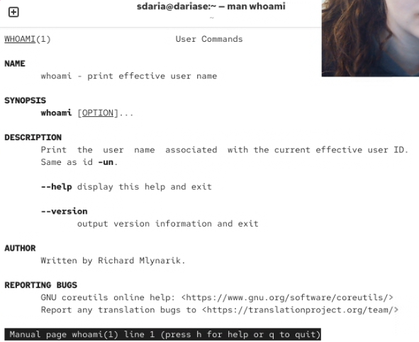

Рисунок 2: Справочное описание команды whoami

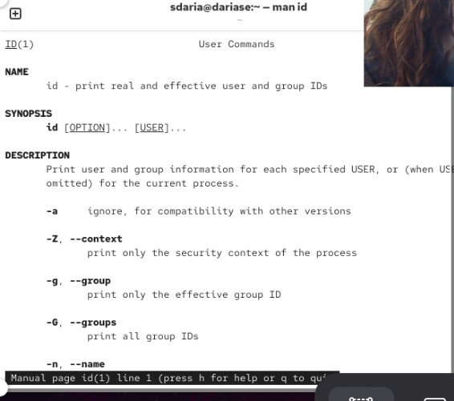

Рисунок 3: Справочное описание команды id

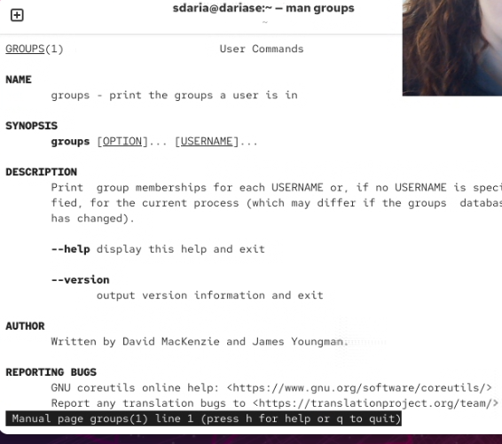

Рисунок 4: Справочное описание команды groups

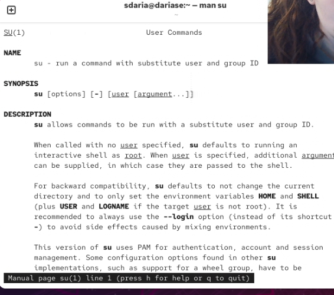

Рисунок 5: Справочное описание команды su

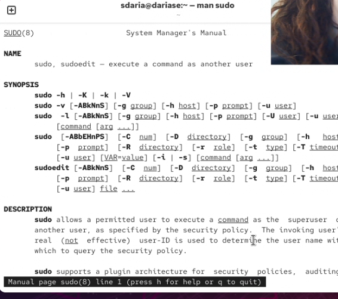

Рисунок 6: Справочное описание команды sudo

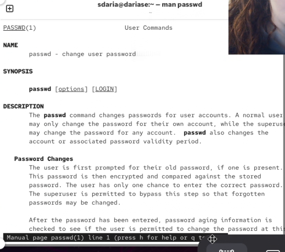

Рисунок 7: Справочное описание команды passwd

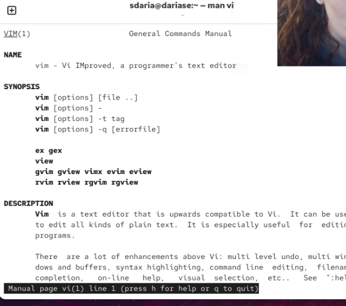

Рисунок 8: Справочное описание команды vi

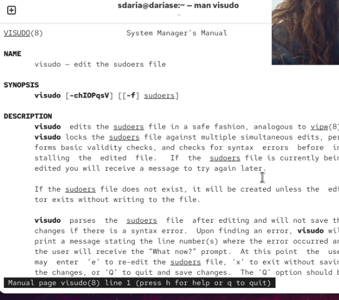

Рисунок 9: Справочное описание команды visudo

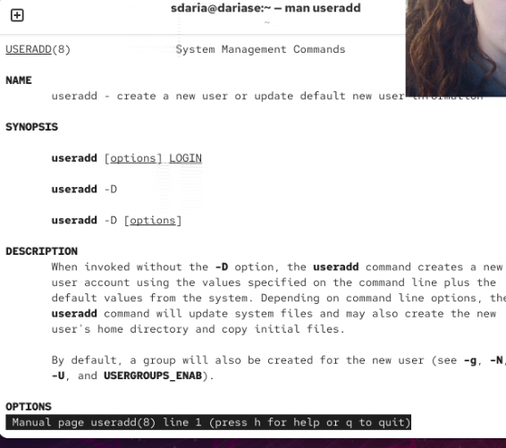

Рисунок 10: Справочное описание команды useradd

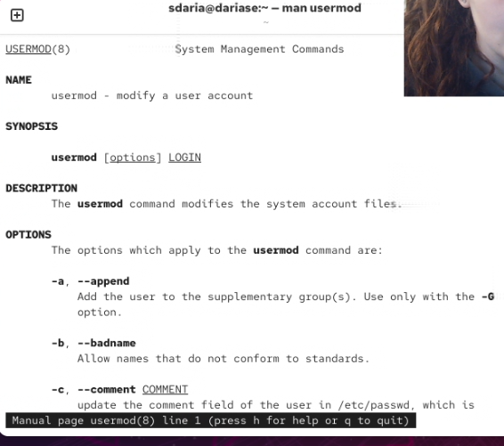

Рисунок 11: Справочное описание команды usermod

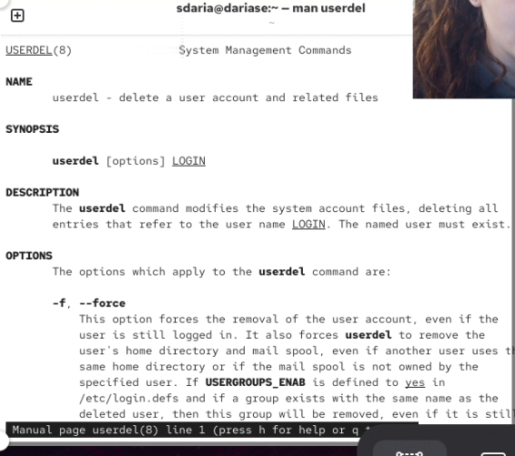

Рисунок 12: Справочное описание команды userdel

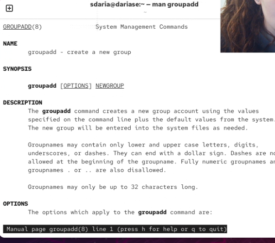

Рисунок 13: Справочное описание команды groupadd

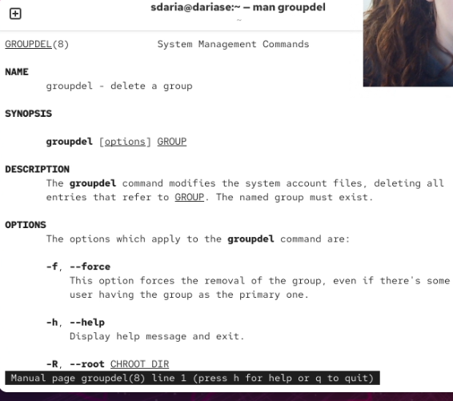

Рисунок 14: Справочное описание команды groupdel

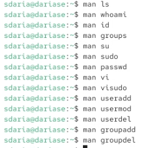

Рисунок 15: Все команды man

2. Переключение учётных записей пользователей.

Входим в систему под обычным пользователем, открываем терминал, определяем какую учётную запись используем и выводим более подробную информацию с помощью команд whoami и id.

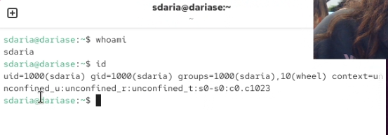

Рисунок 16: Команды whoami и id.

Мы получили информацию о пользователе и его группах.

Переключаемся на пользователя root и выводим подробную информацию о нём.

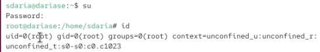

Рисунок 17: Команды su и id.

Возвращаемся к своей учетной записи и находим строку с %wheel в файле sudoers.

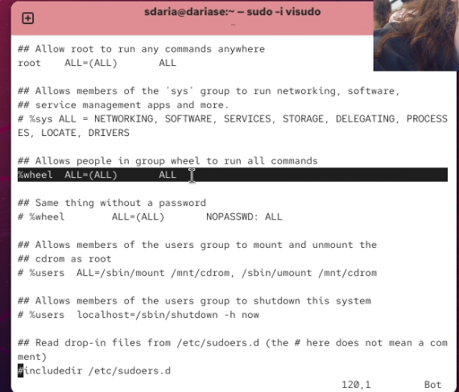

Рисунок 18: Команда sudo -i visudo.

Далее создаём пользователя alice, входящего в группу wheel, задаём пароль и проверяем, входит ли новый пользователь в группу wheel.

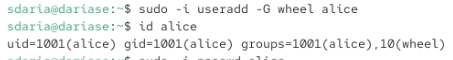

Рисунок 19: Создание нового пользователя с помощью команды useradd.

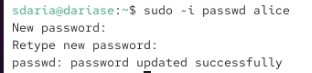

Рисунок 20: Задавание пароля пользователю.

Переходим в новую учетную запись пользователя alice и создаём в нем новую - bob.

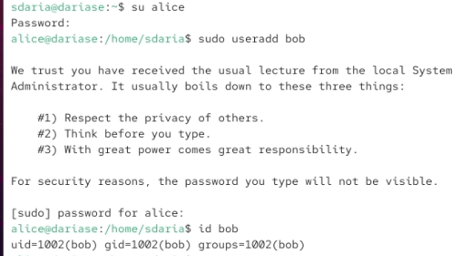

Рисунок 21: Создали учетную запись bob, находясь при этом в alice, посмотрели, в какие группы входит bob с помощью команды id

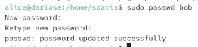

Рисунок 22: Задавание пароля пользователю bob.

3. Создание учётных записей пользователей.

Переключаемся на пользователя root и открываем файл конфиурации для редактирования с помощью команды vim.

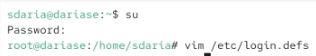

Рисунок 23: Команды su и vim.

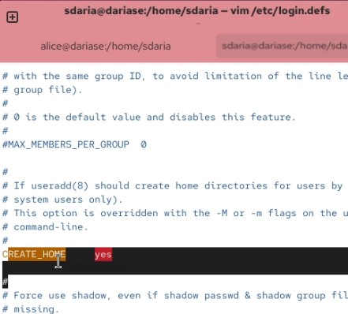

Рисунок 24: Проверяем параметр create_home в значении yes.

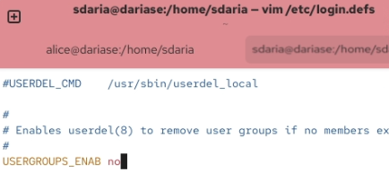

Рисунок 25: Изменяем параметр usergroups_enab в значение no из значения yes.

Далее переходим в каталог /etc/skel и создаем в нем новые каталоги.